# More linear Regression with brms (Exercise)

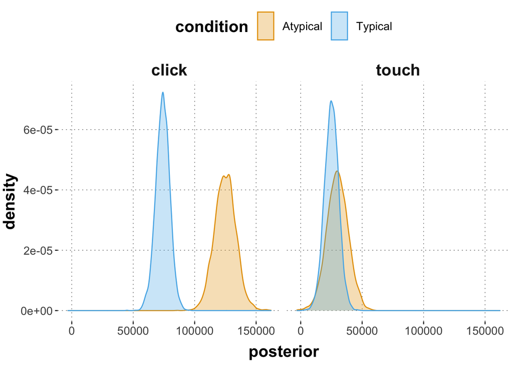

```r
posteriors2 <- model2 %>%
  spread_draws(b_Intercept,
               b_conditionTypical,
               b_grouptouch,
               `b_conditionTypical:grouptouch`) %>%
  mutate(Atypical_click = b_Intercept,
         Typical_click = b_Intercept + b_conditionTypical,
         Atypical_touch = b_Intercept + b_grouptouch,
         Typical_touch = b_Intercept + b_conditionTypical + b_grouptouch +
           `b_conditionTypical:grouptouch`) %>%
  select(Atypical_click, Typical_click, Atypical_touch, Typical_touch) %>%
  gather(key = "parameter", value = "posterior") %>%
   mutate(group = ifelse(parameter == "Atypical_click"
                         | parameter == "Typical_click", "click", "touch"),
         condition = ifelse(parameter == "Atypical_click"
                            | parameter == "Atypical_touch", "Atypical", "Typical"))

ggplot(data = posteriors2, aes(x = posterior, color = condition, fill = condition)) +
  geom_density(alpha = 0.3) +
  facet_grid(~ group)
```

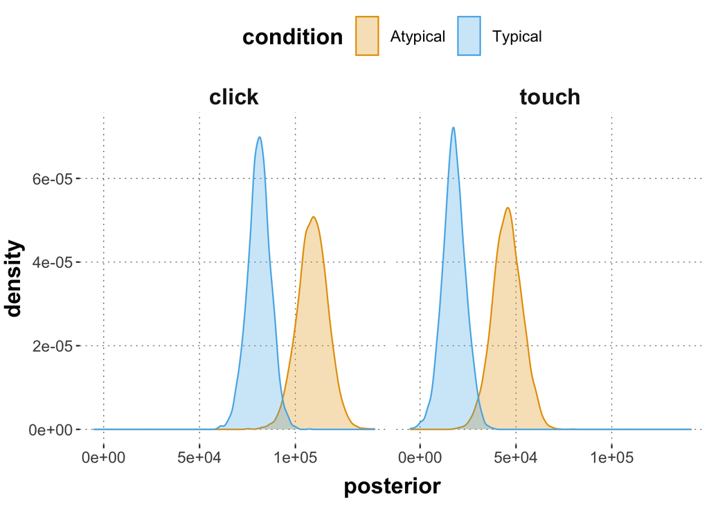

```r
ggplot(data = posteriors1, aes(x = posterior, color = condition, fill = condition)) +
  geom_density(alpha = 0.3) +
  facet_grid(~ group)
```

```r
model1
```

```
##  Family: gaussian
##   Links: mu = identity; sigma = identity
## Formula: AUC ~ group + condition
##    Data: dolphin_agg (Number of observations: 38)
## Samples: 4 chains, each with iter = 2000; warmup = 1000; thin = 1;
##          total post-warmup samples = 4000
##
## Population-Level Effects:
##                   Estimate Est.Error  l-95% CI  u-95% CI Rhat Bulk_ESS Tail_ESS
## Intercept        108931.74   7846.74  93277.87 124153.65 1.00     3736     2780
## grouptouch       -63419.77   7662.59 -78432.33 -48574.96 1.00     4393     2843
## conditionTypical -27879.92   8080.10 -44182.70 -11874.04 1.00     3842     3135
##
## Family Specific Parameters:
##       Estimate Est.Error l-95% CI u-95% CI Rhat Bulk_ESS Tail_ESS
## sigma 23270.07   2945.81 18408.24 29885.45 1.00     3206     2810
##
## Samples were drawn using sampling(NUTS). For each parameter, Bulk_ESS
## and Tail_ESS are effective sample size measures, and Rhat is the potential
## scale reduction factor on split chains (at convergence, Rhat = 1).
```

```r
model2
```

```
##  Family: gaussian
##   Links: mu = identity; sigma = identity
## Formula: AUC ~ condition * group
##    Data: dolphin_agg (Number of observations: 38)
## Samples: 4 chains, each with iter = 2000; warmup = 1000; thin = 1;
##          total post-warmup samples = 4000
##
## Population-Level Effects:
##                              Estimate Est.Error   l-95% CI  u-95% CI Rhat
## Intercept                   124824.57   8710.66  107884.45 142066.41 1.00
## conditionTypical            -50858.54  10602.17  -71990.56 -30156.86 1.00
## grouptouch                  -94949.47  12278.34 -119878.35 -70868.65 1.00
## conditionTypical:grouptouch  46046.53  14774.67   16675.23  75021.02 1.00
##                             Bulk_ESS Tail_ESS
## Intercept                       1833     1920
## conditionTypical                1761     2003
## grouptouch                      1623     1695
## conditionTypical:grouptouch     1513     1712
##
## Family Specific Parameters:
##       Estimate Est.Error l-95% CI u-95% CI Rhat Bulk_ESS Tail_ESS
## sigma 20451.49   2533.69 16222.40 25889.72 1.00     2509     2271
##
## Samples were drawn using sampling(NUTS). For each parameter, Bulk_ESS
## and Tail_ESS are effective sample size measures, and Rhat is the potential
## scale reduction factor on split chains (at convergence, Rhat = 1).
```

5. If you compare the posteriors of model 1 (1b) and model 2 (1d), what is the difference?

```r
# The coefficient for atypical examples in the click condition is greater in model 2, because the interaction term adjusts the posterior estimate to fit the data better. Consequently, the other coefficients are influenced, in that they get smaller.
```

## Exercise 2 *HOMEWORK*

- If you need help, take a look at the suggested readings in the lecture, make use of the Forum, make use of the Forum, and also make use of the Forum.
- Use this exercise Rmd-file, solve the exercises marked as homework (this section here) and save the file with your student number and name in the ‘author’ heading.
- ‘Knit’ the document to produce a HTML file. If knitting fails, make use of the Forum ;)
- **Please do not suppress the code in the HTML-Output!**
- Create a ZIP archive called “MATRIKELNR_Lastname_Firstname_ABDA_Week3.zip” containing:
  - an R Markdown file “MATRIKELNR_Lastname_Firstname_ABDA_Week3.Rmd” and
  - a knitted HTML document “MATRIKELNR_Lastname_Firstname_ABDA_Week6.html”
- Upload the ZIP archive on Stud.IP in the homework folder before the deadline. You may upload as many times as you like before the deadline, only your final submission will count.

I prepared an aggregated data frame `dolphin_agg2` for you.

```r
# make correct a factor
dolphin$correct <- as.factor(dolphin$correct)

# aggregate
dolphin_agg2 <- dolphin %>%
  group_by(exemplar, group, condition, correct) %>%
  dplyr::summarize(MAD = median(MAD, na.rm = TRUE))

dolphin_agg2
```

```
## # A tibble: 65 x 5
## # Groups:   exemplar, group, condition [38]
##    exemplar  group condition correct   MAD
##    <chr>     <chr> <chr>     <fct>   <dbl>
##  1 alligator click Typical   0       508.
##  2 alligator click Typical   1        43.0
##  3 alligator touch Typical   0        34.3
##  4 alligator touch Typical   1        11.1
##  5 bat       click Atypical  0        48.3
##  6 bat       click Atypical  1        69.9
##  7 bat       touch Atypical  0       159.
##  8 bat       touch Atypical  1        14.6
##  9 butterfly click Atypical  0       -39.8
## 10 butterfly click Atypical  1       105.
## # … with 55 more rows
```

1. Plot the data (for all combinations of `group`, `condition`, and `correct`) as a point plot. Use `facet_grid` and dodged positions to separate the categories.

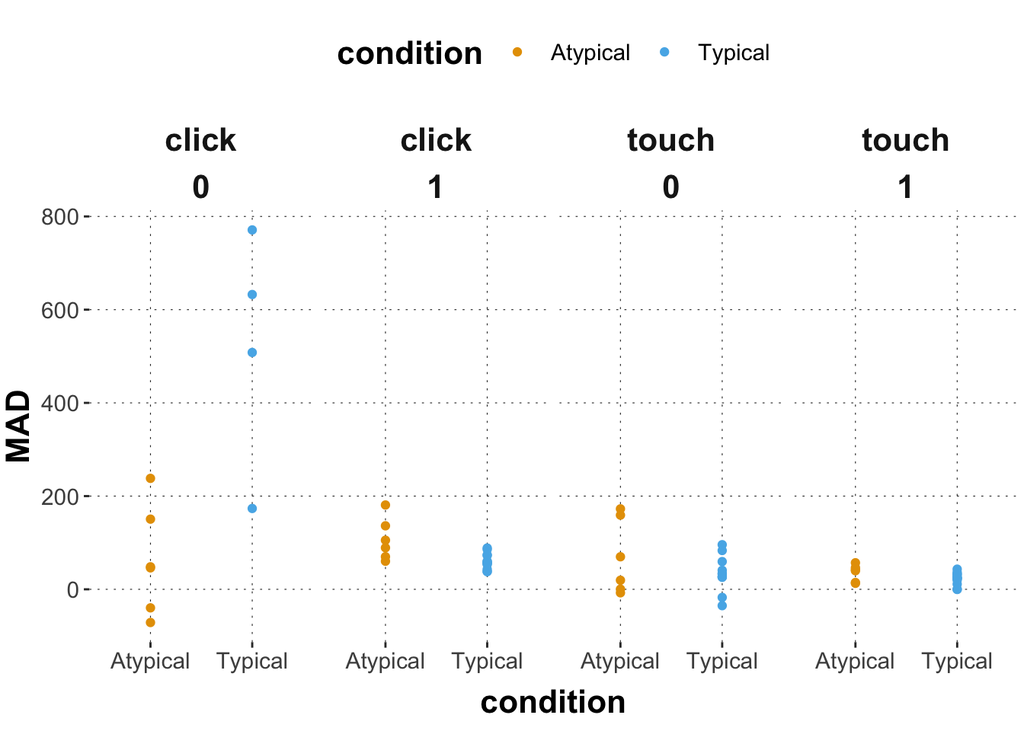

```r
dolphin_agg2 %>%
  ggplot(aes(x = condition, y = MAD, color = condition, fill = condition)) +
  geom_point(position = position_dodge(width = 1)) +
  facet_grid(~ group + correct)
```

2. Run a linear model with `brm` with the dependent variable `MAD` and the independent variables `group`, `condition`, `correct` and an 2-way interaction term for `group x condition`. Run 4 chains, and 2000 iteration per chain. Use `seed = 991`.

```r
model3 = brm(
  formula = MAD ~ group + condition + correct + group:condition,
  data = dolphin_agg2,
  seed = 991,
  chains = 4,
  iter = 2000,
  warmup = 1000)
```

```
## Trying to compile a simple C file
```

[output not shown]

3. Interpret the output by looking at the coefficients. What does the Intercept concretely represent?

```r
model3
```

```
##  Family: gaussian
##   Links: mu = identity; sigma = identity
## Formula: MAD ~ group + condition + correct + group:condition
##    Data: dolphin_agg2 (Number of observations: 65)
## Samples: 4 chains, each with iter = 2000; warmup = 1000; thin = 1;
##          total post-warmup samples = 4000
##
## Population-Level Effects:
##                             Estimate Est.Error l-95% CI u-95% CI Rhat Bulk_ESS
## Intercept                     126.61     38.29    50.11   202.14 1.00     2793
## grouptouch                    -30.91     49.20  -129.40    66.99 1.00     1543
## conditionTypical              110.49     45.85    22.06   198.92 1.00     2051
## correct1                      -95.84     30.84  -156.60   -35.43 1.00     3528
## grouptouch:conditionTypical  -131.61     62.68  -254.43    -7.34 1.00     1386
##                             Tail_ESS
## Intercept                       3106
## grouptouch                      2109
## conditionTypical                2194
## correct1                        2816
## grouptouch:conditionTypical     2072
##
## Family Specific Parameters:
##       Estimate Est.Error l-95% CI u-95% CI Rhat Bulk_ESS Tail_ESS
## sigma   118.23     10.62    99.41   141.56 1.00     3360     2716
##
## Samples were drawn using sampling(NUTS). For each parameter, Bulk_ESS
## and Tail_ESS are effective sample size measures, and Rhat is the potential
## scale reduction factor on split chains (at convergence, Rhat = 1).
```

```r
# The Intercept represents the posterior mean of incorrect answers for atypical examples in the click condition. Now the grouptouch coefficient is the change from our reference level (intercept) to the touch condition (about 31 less), conditionTypical gives us the change from our intercept to typical examples (about 110), correct1 the change from intercept to correct responses (about 96 less) and the interaction term gives us the change from incorrect answers for atypical examples in the click condition to incorrect answers for typical examples in the touch condition (about -132).
```

4. Extract the posterior means and their 95% CrIs for all combination of predictors (correct x condition x group) and plot them as a point plot with the 95% CrIs as error bars.

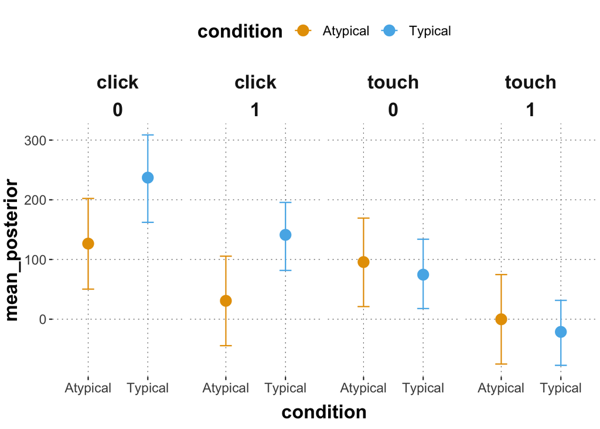

```r
posteriors3 <- model3 %>%
  spread_draws(b_Intercept,
               b_grouptouch,
               b_conditionTypical,
               b_correct1,
               `b_grouptouch:conditionTypical`) %>%
  mutate(Click_Atypical_0 = b_Intercept,
         Click_Typical_0 = b_Intercept + b_conditionTypical,
         Click_Atypical_1 = b_Intercept + b_correct1,
         Click_Typical_1  = b_Intercept + b_conditionTypical + b_correct1,
         Touch_Atypical_0 = b_Intercept + b_grouptouch,
         Touch_Typical_0 = b_Intercept + b_grouptouch + b_conditionTypical +
           `b_grouptouch:conditionTypical`,
         Touch_Atypical_1 = b_Intercept + b_grouptouch + b_correct1,
         Touch_Typical_1 = b_Intercept + b_grouptouch + b_conditionTypical + b_correct1 +
           `b_grouptouch:conditionTypical`) %>%
  select(Click_Atypical_0, Click_Typical_0, Click_Atypical_1, Click_Typical_1,
         Touch_Atypical_0, Touch_Typical_0, Touch_Atypical_1, Touch_Typical_1) %>%
  gather(key = "parameter", value = "posterior") %>%
  mutate(group = ifelse(parameter == "Click_Atypical_0"
                        | parameter == "Click_Typical_0"
                        | parameter == "Click_Atypical_1"
                        | parameter == "Click_Typical_1", "click", "touch"),
         condition = ifelse(parameter == "Click_Atypical_0"
                            | parameter == "Touch_Atypical_0"
                            | parameter == "Click_Atypical_1"
                            | parameter == "Touch_Atypical_1", "Atypical", "Typical"),
         correct = ifelse(parameter == "Click_Atypical_1"
                          | parameter == "Click_Typical_1"
                          | parameter == "Touch_Atypical_1"
                          | parameter == "Touch_Typical_1", "1", "0"))

posteriors_agg <- posteriors3 %>%
  group_by(group, condition, correct) %>%
  summarise(mean_posterior = mean(posterior),
            `95lowerCrI` = HDInterval::hdi(posterior, credMass = 0.95)[1],
            `95higherCrI` = HDInterval::hdi(posterior, credMass = 0.95)[2])

posteriors_agg %>%
  ggplot(aes(x = condition, y = mean_posterior, color = condition, fill = condition)) +
  geom_point(position = position_dodge(1), size = 4) +
  geom_errorbar(aes(ymin = `95lowerCrI`, ymax = `95higherCrI`), width = 0.2) +
  facet_grid(~ group + correct)
```

5. Create a point plot that plots the data against the posterior means and 95% CrIs.

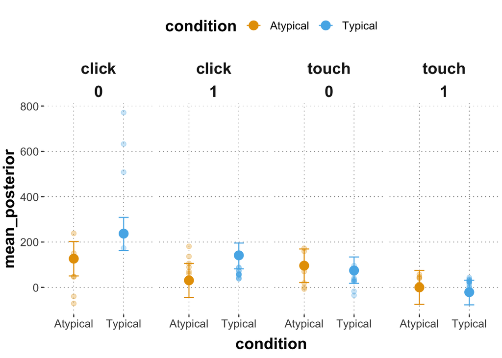

```r
posteriors_agg %>%
  ggplot(aes(x = condition, y = mean_posterior, color = condition, fill = condition)) +
  geom_errorbar(aes(ymin = `95lowerCrI`, ymax = `95higherCrI`), width = 0.2,
                position = position_dodge(0.4)) +
  geom_point(size = 4) +
  geom_point(data = dolphin_agg2, aes(x = condition, y = MAD), alpha = 0.3, size = 2) +
  facet_grid(~group + correct)
```

Bonus: (f) run the model with a three-way interaction `group x condition x correct`. Extract the posteriors for each individual combination of predictor levels and plot them against the data as in 2d.

```r
model4 <- brm(
  formula = MAD ~ group * condition * correct,
  data = dolphin_agg2
) # by default again 4 chains with 2000 iterations and 1000 warm up
```

```
## recompiling to avoid crashing R session
```

```
## Trying to compile a simple C file
```

[output not shown]

```r
model4
```

```
##  Family: gaussian
##   Links: mu = identity; sigma = identity
## Formula: MAD ~ group * condition * correct
##    Data: dolphin_agg2 (Number of observations: 65)
## Samples: 4 chains, each with iter = 2000; warmup = 1000; thin = 1;
##          total post-warmup samples = 4000
##
## Population-Level Effects:
##                                      Estimate Est.Error l-95% CI u-95% CI Rhat
## Intercept                               59.21     31.94    -2.57   121.42 1.00
## grouptouch                               8.80     44.65   -78.22    95.51 1.00
## conditionTypical                       460.05     50.29   362.68   562.04 1.00
## correct1                                46.53     44.34   -44.10   132.14 1.00
## grouptouch:conditionTypical           -496.59     63.65  -622.11  -373.40 1.00
## grouptouch:correct1                    -81.37     62.50  -203.99    41.87 1.00
## conditionTypical:correct1             -508.42     63.48  -632.64  -385.34 1.00
## grouptouch:conditionTypical:correct1   532.12     83.65   368.07   690.44 1.00
##                                      Bulk_ESS Tail_ESS
## Intercept                                2067     2363
## grouptouch                               1852     2283
## conditionTypical                         1767     1940
## correct1                                 1825     2143
## grouptouch:conditionTypical              1514     1742
## grouptouch:correct1                      1729     1877
## conditionTypical:correct1                1588     2079
## grouptouch:conditionTypical:correct1     1534     1659
##
## Family Specific Parameters:
##       Estimate Est.Error l-95% CI u-95% CI Rhat Bulk_ESS Tail_ESS
## sigma    75.73      6.95    63.57    90.87 1.00     2910     2792
##
## Samples were drawn using sampling(NUTS). For each parameter, Bulk_ESS
## and Tail_ESS are effective sample size measures, and Rhat is the potential
## scale reduction factor on split chains (at convergence, Rhat = 1).
```

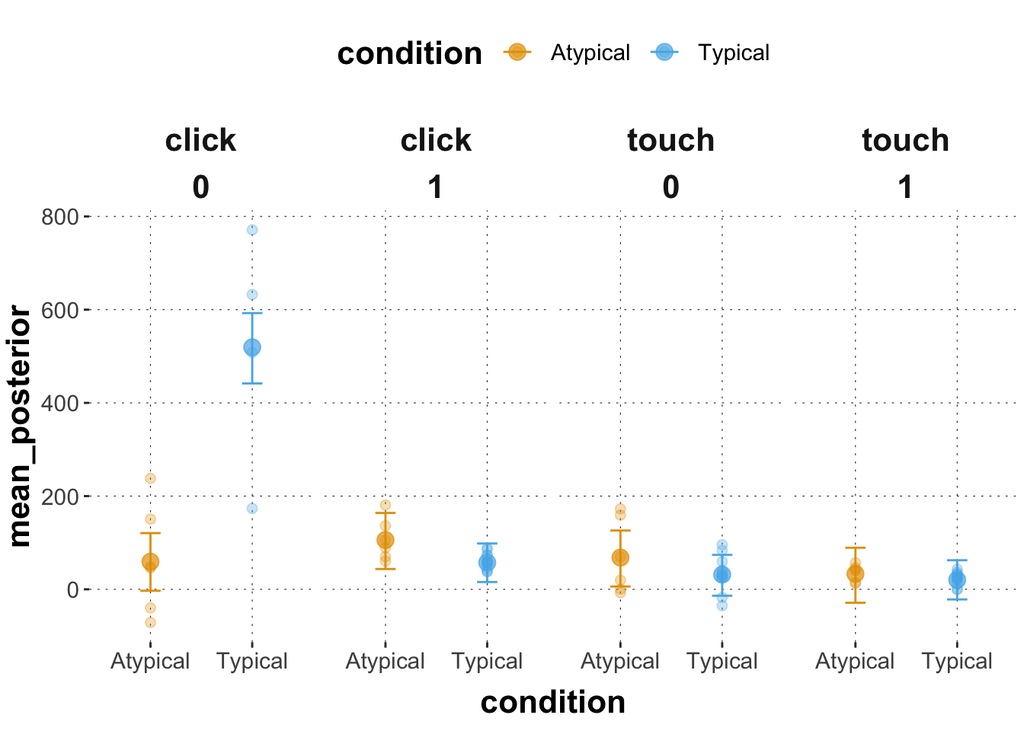

```r
posteriors4 <- model4 %>%
  spread_draws(b_Intercept,
               b_grouptouch,
               b_conditionTypical,
               b_correct1,
               `b_grouptouch:conditionTypical`,
               `b_grouptouch:correct1`,
               `b_conditionTypical:correct1`,
               `b_grouptouch:conditionTypical:correct1`) %>%
  mutate(Click_Atypical_0 = b_Intercept,
         Click_Typical_0 = b_Intercept + b_conditionTypical,
         Click_Atypical_1 = b_Intercept + b_correct1,
         Click_Typical_1  = b_Intercept + b_conditionTypical + b_correct1 +
           `b_conditionTypical:correct1`,
         Touch_Atypical_0 = b_Intercept + b_grouptouch,
         Touch_Typical_0 = b_Intercept + b_grouptouch + b_conditionTypical +
           `b_grouptouch:conditionTypical`,
         Touch_Atypical_1 = b_Intercept + b_grouptouch + b_correct1 + `b_grouptouch:correct1`,
         Touch_Typical_1 = b_Intercept + b_grouptouch + b_conditionTypical + b_correct1 +
           `b_grouptouch:conditionTypical` +
           `b_grouptouch:correct1` +
           `b_conditionTypical:correct1` +
           `b_grouptouch:conditionTypical:correct1`) %>%
  select(Click_Atypical_0, Click_Typical_0, Click_Atypical_1, Click_Typical_1,
         Touch_Atypical_0, Touch_Typical_0, Touch_Atypical_1, Touch_Typical_1) %>%
  gather(key = "parameter", value = "posterior") %>%
  mutate(group = ifelse(parameter == "Click_Atypical_0"
                        | parameter == "Click_Typical_0"
                        | parameter == "Click_Atypical_1"
                        | parameter == "Click_Typical_1", "click", "touch"),
         condition = ifelse(parameter == "Click_Atypical_0"
                            | parameter == "Touch_Atypical_0"
                            | parameter == "Click_Atypical_1"
                            | parameter == "Touch_Atypical_1", "Atypical", "Typical"),
         correct = ifelse(parameter == "Click_Atypical_1"
                          | parameter == "Click_Typical_1"
                          | parameter == "Touch_Atypical_1"
                          | parameter == "Touch_Typical_1", "1", "0"))

posteriors_agg2 <- posteriors4 %>%
  group_by(group, condition, correct) %>%
  summarise(mean_posterior = mean(posterior),
            `95lowerCrI` = HDInterval::hdi(posterior, credMass = 0.95)[1],
            `95higherCrI` = HDInterval::hdi(posterior, credMass = 0.95)[2])

posteriors_agg2 %>%
  ggplot(aes(x = condition, y = mean_posterior, color = condition, fill = condition)) +
  geom_errorbar(aes(ymin = `95lowerCrI`, ymax = `95higherCrI`), width = 0.2,
                position = position_dodge(0.4)) +
  geom_point(size = 3.5, alpha = 0.7) +
  geom_point(data = dolphin_agg2, aes(x = condition, y = MAD), alpha = 0.3, size = 2) +
  facet_grid(~group + correct)
```